# POTD 03 - Markdown

Simon Chen

10/12/2021

Run the following code to create a tibble using the `state.x77` data.

```r
# Import libraries.
library(tidyverse)
```

```r
library(ggplot2)
library(magrittr)
# Load the dataset and create a tibble.
dat <- data.frame(state.x77)
dat <- tibble(dat)

# Add the region and division and abbreviation information
dat$Region <- state.region
dat$Division <- state.division
dat$abbrev <- state.abb
print(dat, n = 50, width = 100)
```

```
## # A tibble: 50 × 11
##    Population Income Illiteracy Life.Exp Murder HS.Grad Frost   Area
##         <dbl>  <dbl>      <dbl>    <dbl>  <dbl>   <dbl> <dbl>  <dbl>
##  1       3615   3624        2.1     69.0   15.1    41.3    20  50708
##  2        365   6315        1.5     69.3   11.3    66.7   152 566432
##  3       2212   4530        1.8     70.6    7.8    58.1    15 113417
##  4       2110   3378        1.9     70.7   10.1    39.9    65  51945
##  5      21198   5114        1.1     71.7   10.3    62.6    20 156361
##  6       2541   4884        0.7     72.1    6.8    63.9   166 103766
##  7       3100   5348        1.1     72.5    3.1    56     139   4862
##  8        579   4809        0.9     70.1    6.2    54.6   103   1982
##  9       8277   4815        1.3     70.7   10.7    52.6    11  54090
## 10       4931   4091        2       68.5   13.9    40.6    60  58073
## 11        868   4963        1.9     73.6    6.2    61.9     0   6425
## 12        813   4119        0.6     71.9    5.3    59.5   126  82677
```

[output cut: 90 more lines]

## Task 1

Create a scatterplot of life expectancy on the horizontal and illiteracy rate on the vertical and color the point by state region.

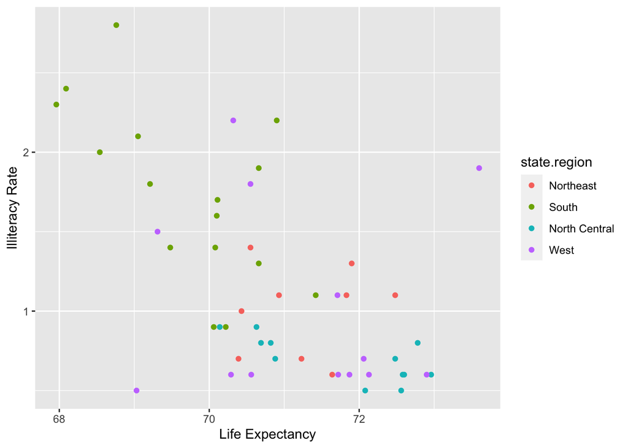

```r
ggplot(data = dat, mapping = aes(x=Life.Exp, y=Illiteracy, color=state.region)) +
  geom_point() +
  xlab('Life Expectancy') +
  ylab('Illiteracy Rate')
```

## Task 2

Now, instead of using **geom_point()**, use **geom_text** to create the same plot as above but with the state abbreviations plotted for each point instead of circles. It should look like this:

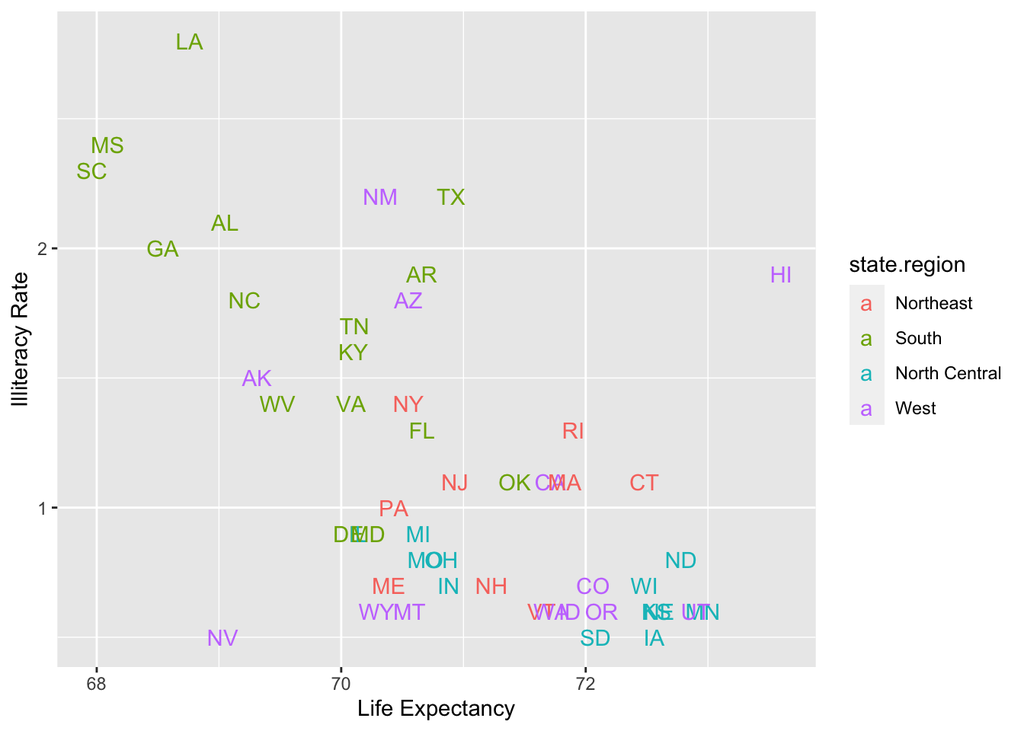

```r
ggplot(data = dat, mapping = aes(x=Life.Exp, y=Illiteracy, color=state.region)) +
  geom_text(aes(label=abbrev)) +
  xlab('Life Expectancy') +
  ylab('Illiteracy Rate')
```

## Task 3

Filter the data set to include only states that have illteracy rates higher than 1.6 and life expectancies lower than 75. Verify visually that your results agree with your plot.

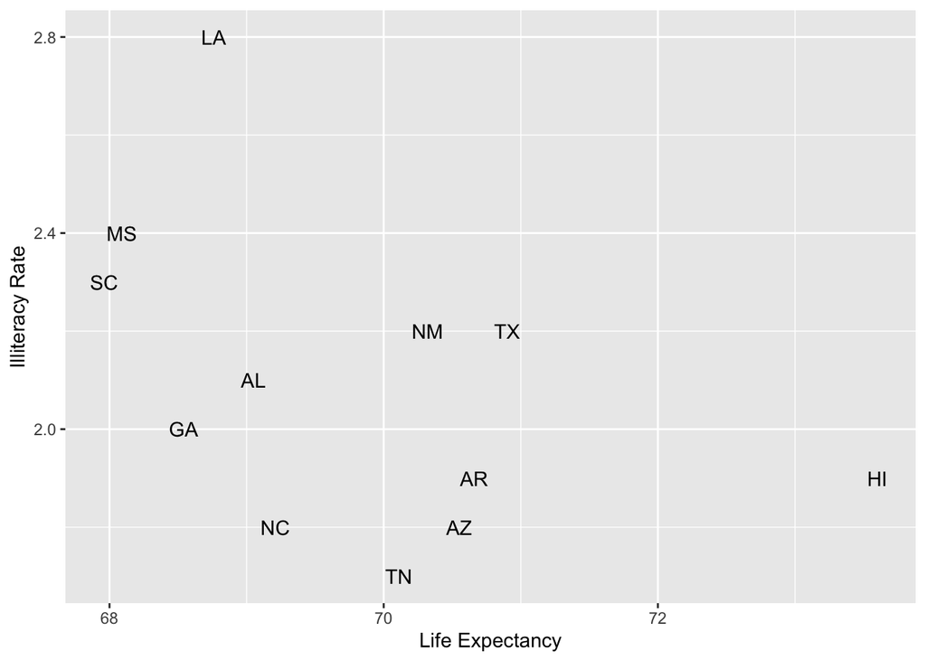

```r
# Filter the data
f_dat <-filter(dat, Illiteracy > 1.6, Life.Exp < 75)
# Verify
ggplot(data = f_dat, aes(x=Life.Exp, y=Illiteracy)) +
  geom_text(aes(label=abbrev)) +
  xlab('Life Expectancy') +
  ylab('Illiteracy Rate')
```

## Task 4

Create a data set that only contains Hawaii by filtering on region and life expectancy.

```r
hawaii_dat <- filter(dat, Region == 'West', Life.Exp == 73.6)
hawaii_dat
```

```
## # A tibble: 1 × 11
##   Population Income Illiteracy Life.Exp Murder HS.Grad Frost  Area Region
##        <dbl>  <dbl>      <dbl>    <dbl>  <dbl>   <dbl> <dbl> <dbl> <fct>
## 1        868   4963        1.9     73.6    6.2    61.9     0  6425 West
## # … with 2 more variables: Division <fct>, abbrev <chr>
```

## Task 5

Arrange the data, first in ascending then in descending order, based on state area.  
Which are the three states with most area? Which are the three states with least area?

```r
# Ascending order.
asc_dat <- arrange(dat, Area)
print(head(asc_dat, 3))
```

```
## # A tibble: 3 × 11
##   Population Income Illiteracy Life.Exp Murder HS.Grad Frost  Area Region
##        <dbl>  <dbl>      <dbl>    <dbl>  <dbl>   <dbl> <dbl> <dbl> <fct>
## 1        931   4558        1.3     71.9    2.4    46.4   127  1049 Northeast
## 2        579   4809        0.9     70.1    6.2    54.6   103  1982 South
## 3       3100   5348        1.1     72.5    3.1    56     139  4862 Northeast
## # … with 2 more variables: Division <fct>, abbrev <chr>
```

```r
print(head(asc_dat, 3)$abbrev)
```

```
## [1] "RI" "DE" "CT"
```

```r
# Descending order.
des_dat <- arrange(dat, desc(Area))
head(des_dat, 3)
```

```
## # A tibble: 3 × 11
##   Population Income Illiteracy Life.Exp Murder HS.Grad Frost   Area Region
##        <dbl>  <dbl>      <dbl>    <dbl>  <dbl>   <dbl> <dbl>  <dbl> <fct>
## 1        365   6315        1.5     69.3   11.3    66.7   152 566432 West
## 2      12237   4188        2.2     70.9   12.2    47.4    35 262134 South
## 3      21198   5114        1.1     71.7   10.3    62.6    20 156361 West
## # … with 2 more variables: Division <fct>, abbrev <chr>
```

## Task 6

Use mutate() to add a variable to the data frame that gives state area in square kilometers (instead of square miles).

```r
dat <- mutate(dat, Area_in_square_km = Area * 2.59)
```

## Task 7

Create a data frame with four variables: state population, state area, the number of people per square mile and the number of people per square kilometer.

```r
four_dat <- mutate(dat, pop_per_square_mile = Population / Area,
         pop_per_square_km = Population / Area_in_square_km) %>%
  select(Population, Area, pop_per_square_mile, pop_per_square_km)
head(four_dat)
```

```
## # A tibble: 6 × 4
##   Population   Area pop_per_square_mile pop_per_square_km
##        <dbl>  <dbl>               <dbl>             <dbl>
## 1       3615  50708            0.0713            0.0275
## 2        365 566432            0.000644          0.000249
## 3       2212 113417            0.0195            0.00753
## 4       2110  51945            0.0406            0.0157
## 5      21198 156361            0.136             0.0523
## 6       2541 103766            0.0245            0.00945
```

## Task 8

I want to use count function to get a gist of this data.

```r
count(population)
```

[output not shown]